# HW5

## Домашнее задание 5.Вычисление параметров для молекулярной механики.

### Горохов Никита

```python
import subprocess
import numpy as np
import matplotlib.pyplot as plt
from scipy import optimize
%matplotlib inline
```

Для начала создадим функции, которые генерируют содержимое входного файла для запуска orca, в зависимости от значения изменяемых параметров (длина связи и два угла).

```python
def generate_zmatrix(bond_length=1.52986, valence_angle=111.200):
    # Эта функция создает "содержимое" входного файля для запуска ORCA
    # здесь мы изменяем длину свящи и валентный угол
    # В третьей строчке 4 число - это длина связи (C-C).
    # 5 число - это  валентный угол HCС
    # 6 число - это торсионный угол CC
    inp = '''!HF RHF 6-31G
    * int 0 1
    C 0 0 0 0 0 0
    C 1 0 0 %s 0 0
    H 1 2 0 1.08439 %s 0
    H 1 2 3 1.08439 %s 120
    H 1 2 3 1.08439 %s -120
    H 2 1 3 1.08439 %s 180
    H 2 1 5 1.08439 %s 120
    H 2 1 5 1.08439 %s -120
    *
    ''' % (bond_length, valence_angle, valence_angle, valence_angle, valence_angle,
           valence_angle, valence_angle)
    return inp

def generate_zmatrix_tors(torsion_angle):
    # а здесь мы меняем торсионный угол
    inp = '''!HF RHF 6-31G
    * int 0 1
    C 0 0 0 0 0 0
    C 1 0 0 1.52986 0 0
    H 1 2 0 1.08439 111.200 0
    H 1 2 3 1.08439 111.200 120
    H 1 2 3 1.08439 111.200 -120
    H 2 1 3 1.08439 111.200 %s
    H 2 1 5 1.08439 111.200 %s
    H 2 1 5 1.08439 111.200 %s
    *
    ''' % (torsion_angle, torsion_angle - 60, torsion_angle + 60)
    return inp
```

Создадим четыре вектора (сетки по трем изменяемым параметрам)

```python
bond_length_1 = np.arange(1.32986, 1.72987, 0.02)
bond_length_2 = np.arange(0.52986, 2.52987, 0.1)
valence_angle = np.arange(109.2, 113.21, 0.2)
torsion_angle = np.arange(180, -181, -12)
```

Функция для запуска orca. Данная функция возвращает конечное значение энергии.

```python
def run_orca(inp):
    with open('orca.inp', 'w') as outfile:
        outfile.write(inp)
    p = subprocess.Popen("/home/shad/progs/bin/orca orca.inp",
                          shell=True, stdout=subprocess.PIPE, stderr=subprocess.PIPE)
    out=p.communicate()[0]

    # extract energy: FINAL SINGLE POINT ENERGY'
    # извлекаем число после этой фразы
    for i in out.splitlines():
        if i.startswith("FINAL SINGLE POINT ENERGY"):
            return(float(i[len("FINAL SINGLE POINT ENERGY"):]))
    # если программа дайдет до этого этапа, значит произошла ошибка
    print "error"
    exit(1)
```

Функция для апрокисмации полученных значений энергии и последующей визуализации. Вид аппроксимирующей функции зависит от параметра fit_type:

- "polinomial": $ a_0 + a_1 x + a_2 x^2 + a_3 x^{-1} + a_4 x^{-2}$, 5 параметра
- "trigonometric": $ a_0 + (a_1 + a_2 x) sin(a_3 + a_4 x) + (a_5 + a_6 x) cos(a_7 + a_8 x) $, 9 параметров
- "exponential": $ a_0 + (a_1 + a_2 x) e^{a_3 + a_4 x} $, 5 параметров

В качестве результата выводятся значения параметров и значение нормы невязки

```python
def fit_and_plot(x, y, fit_type):

    if fit_type == "polinomial":
        fitfunc = lambda p, x: p[0] + p[1]*x + p[2]*x*x + p[3]/x + p[4]/x/x
        p_0 = np.zeros(5)
    elif fit_type == "trigonometric":
        fitfunc = lambda p, x: p[0] + (p[1] + p[2]*x) * np.sin(p[3] + p[4]*x) + (p[5] + p[6]*x) * np.cos(p[7] + p[8]*x)
        p_0 = np.ones(9)
    elif fit_type == "exponential":
        fitfunc = lambda p, x: p[0] + (p[1] + p[2]*x) * np.exp(p[3] + p[4]*x)
        p_0 = np.ones(5)
    else:
        print "Invalid fit_type"
        exit(1)

    errfunc = lambda p, x, y: fitfunc(p, x) - y # Error function

    p1, success = optimize.leastsq(errfunc, p_0, args=(x, y))
    print "Optimized params:", p1
    print "Function error = ", np.linalg.norm(errfunc(p1, x, y))

    #Plot it
    plt.plot(x, y, "ro", x, fitfunc(p1, x),"r-", c='blue', alpha=0.5)
    step = (x[1] - x[0])
    plt.xlim(x[0] - 5*step, x[-1] + 5*step)
    plt.show()
```

```python
calculated_energy1 = []
for length in bond_length_1:
    calculated_energy1.append(run_orca(generate_zmatrix(bond_length=length)))
```

```
Optimized params: [-72.76215158  -1.63551232   0.18228247 -10.48032929   6.10070361]
Function error =  4.159844861129603e-06
```

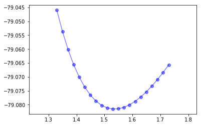

```python
fit_and_plot(bond_length_1, calculated_energy1, "polinomial")
```

Полученые значения с хорошей точностью апроксимировались полиномами второй степени. Минимум находится в точке 1.527. Теперь вместо длины связи будем варировать валентный угол.

```python
calculated_energy2 = []
for angle in valence_angle:
    calculated_energy2.append(run_orca(generate_zmatrix(valence_angle=angle)))
```

```
Optimized params: [-4.14416769e+01 -2.84364441e-01  8.24319611e-04 -2.36490124e+03
  6.25134091e+04]
Function error =  1.1034818696331677e-07
```

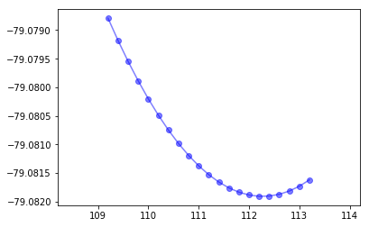

```python
fit_and_plot(valence_angle, calculated_energy2, "polinomial")
```

Данные очень хорошо апроксимируются полиномиальной функцией. Далее будем варировать торсионный угол. В качестве апроксимирующей функции будем исполльзовать тригонометрическую. Так как она лучше себя показала.

```python
calculated_energy3 = []
for angle in torsion_angle:
    calculated_energy3.append(run_orca(generate_zmatrix_tors(angle)))
```

```
Optimized params: [-7.90825389e+01  4.11047751e-02 -4.19953030e-05  9.36757505e-02
  9.95319362e-01  4.27065649e-02 -4.15910964e-05  1.68461372e+00
  9.95321060e-01]
Function error =  1.4502342349811954e-05
```

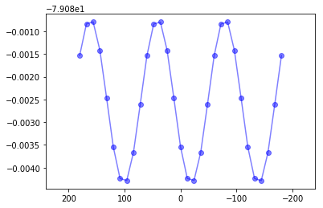

```python
fit_and_plot(torsion_angle, calculated_energy3, "trigonometric")
```

У данного приближения наблюдается три локальных минимума. Увеличи шаг с 0.02 до 0.1 ангстрема.

```python
calculated_energy4 = []
for length in bond_length_2:
    calculated_energy4.append(run_orca(generate_zmatrix(bond_length=length)))
```

```
Optimized params: [-84.31915755   3.47738501  -0.6276318    0.59070134   2.29739239]
Function error =  0.08637816298656245
```

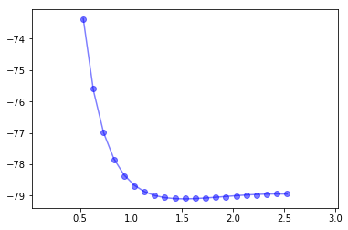

```python
fit_and_plot(bond_length_2, calculated_energy4, "polinomial")
```